# Soc 723

Spring 2024

Stephen Vaisey

# Part I: Theoretical background

## Asking causal questions

- Does more education *cause* higher wages?
- Does participating in a job training program *cause* a higher probability of employment?
- Do boycotts *cause* a drop in a company’s share price?
- These are tough questions!

## Threats to causal inference

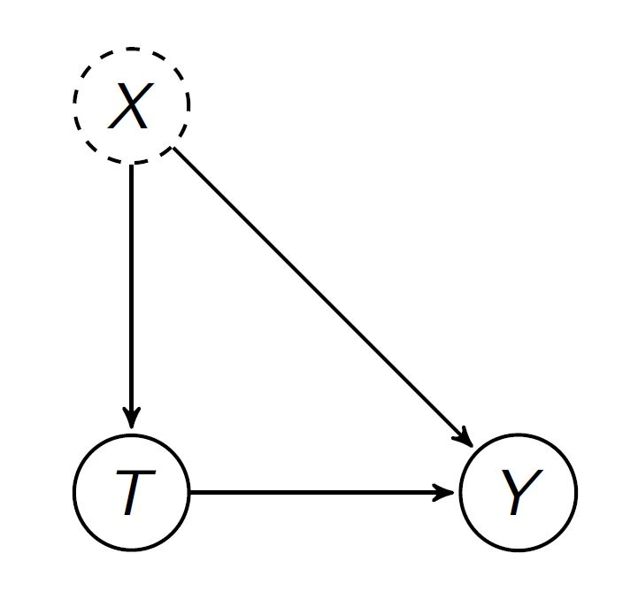

## Key term: Identification

How do we *identify* the effect of a treatment (cause) on an outcome?

## Experimental independent variables

- What is an experiment?
- How do experiments solve the problem we just talked about?

## Experiments are great!

Assuming successful randomization to treatment and control, you **know** it’s the treatment that’s causing the effect.

## Experiments can’t do everything

- ethics
- external validity
- often non-representative
- some treatments are hard or impossible to assign randomly
  - motherhood
  - divorce
  - boycotts

## Why experiments work

## Some notation

$T$ a binary treatment variable

$Y$ the value of the outcome we observe

$Y^0$ the value the outcome *would* take if $T=0$

$Y^1$ the value the outcome *would* take if $T=1$

*Let’s think about the last two a bit more carefully…*

## The world before the experiment

| Subject | Y0 | Y1 | T | Y |
| --- | --- | --- | --- | --- |
| Andrew | 2 | 3 | NA | NA |
| Barb | 3 | 4 | NA | NA |
| Catherine | 3 | 4 | NA | NA |
| David | 2 | 3 | NA | NA |

What do these numbers mean?

## The world after the experiment

| Subject | Y0 | Y1 | T | Y |
| --- | --- | --- | --- | --- |
| Andrew | NA | 3 | 1 | 3 |
| Barb | 3 | NA | 0 | 3 |
| Catherine | NA | 4 | 1 | 4 |
| David | 2 | NA | 0 | 2 |

$$Y = TY^1+(1-T)Y^0$$

## Potential outcomes and counterfactuals

- $Y = Y^1$ for $T = 1$
- $Y = Y^0$ for $T = 0$
- We *can’t know* $Y^1$ for those who are $T=0$
- We *can’t know* $Y^0$ for those who are $T=1$
- This is the **fundamental problem of causal inference.**

## Potential outcomes and counterfactuals

- $Y^0$ and $Y^1$ are *potential outcomes*.
- In the real world, $T$ is either 1 or 0 for each case.
- We see $Y^1$ or $Y^0$, but never both.
- When $T=0$, $Y^1$ is *counterfactual*
- When $T=1$, $Y^0$ is *counterfactual*

## What do we want to know?

We really care about the difference between $Y^0$ and $Y^1$. (Why?)

Let $\delta_i = y^1_i - y^0_i$

$E[\delta]=E[Y^1-Y^0]$

$E[\delta]=E[Y^1]-E[Y^0]$

This is the definition of a **treatment effect**.

## Assume an experiment: what is $E[\delta]$?

| Subject | Y0 | Y1 | T | Y |
| --- | --- | --- | --- | --- |
| Andrew | 2 | 3 | NA | NA |
| Barb | 3 | 4 | NA | NA |
| Catherine | 3 | 4 | NA | NA |
| David | 2 | 3 | NA | NA |

If we could see this (invisible) world, what would be our calculation of the treatment effect?

**Why can’t we make these calculations in real life?**

## Assume an experiment: what is $E[\delta]$?

| Subject | Y0 | Y1 | T | Y |
| --- | --- | --- | --- | --- |
| Andrew | NA | 3 | 1 | 3 |
| Barb | 3 | NA | 0 | 3 |
| Catherine | NA | 4 | 1 | 4 |
| David | 2 | NA | 0 | 2 |

**Does this give us the right answer? Why?**

## Why do experiments work?

$T \bot Y^0$

$T \bot Y^1$

$E[Y^0 | T = 0] = E[Y^0 | T = 1 ]$

$E[Y^1 | T = 0] = E[Y^1 | T = 1 ]$

## Or in other words…

In a properly executed experiment, there is no association between the potential outcome variables and treatment assignment.

$E[Y^0 | T = 0] \simeq E[Y^0]$

$E[Y^1 | T = 1] \simeq E[Y^1]$

So…

$E[\delta] = E[Y|T=1]-E[Y|T=0]$

The difference between the treatment average and the control average

## What is this treatment effect?

$E[\delta]$ is the expected value (mean) of the difference between each unit’s value of $Y^1$ and $Y^0$. It is the **average treatment effect (ATE).** In a sample, this is the **sample average treatment effect (SATE).**

Even though the individual differences are unobservable (because either $Y^0$ or $Y^1$ will be counterfactual for each unit), we can estimate the mean difference via experiment.

$$\text{SATE} = \frac{1}{n}\sum_{i=1}^{n}(y^1_i - y^0_i)$$

## Randomization

- Experiments identify the SATE because cases are randomly assigned to the treatment and control group and are, therefore, identical *on average*, on all pre-treatment characteristics.
- Experiments are sometimes called **randomized controlled trials** (or RCTs)

## Bias in observational data

1. Treated and control cases might be different from each other even in the same treatment state (**baseline bias**)
2. Treated and control cases might respond differently to treatment (**treatment effect heterogeneity**)

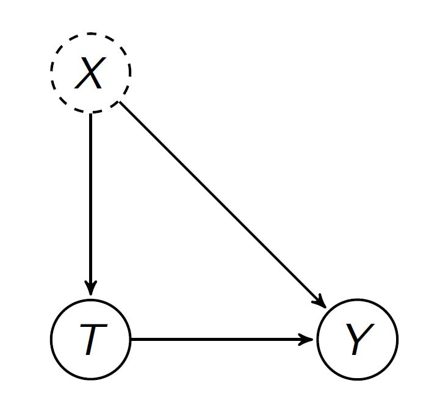

## Key term: baseline bias

| Subject | Y0 | Y1 | T | Y |
| --- | --- | --- | --- | --- |
| Andrew | 4000 | 4000 | NA | NA |
| Barb | 2000 | 2000 | NA | NA |
| Catherine | 3000 | 3000 | NA | NA |
| David | 3000 | 3000 | NA | NA |

## Baseline bias

| Subject | Y0 | Y1 | T | Y |
| --- | --- | --- | --- | --- |
| Andrew | NA | 4000 | 1 | 4000 |
| Barb | 2000 | NA | 0 | 2000 |
| Catherine | NA | 3000 | 1 | 3000 |
| David | 3000 | NA | 0 | 3000 |

Here, the people who go to college have different *baseline* earnings that have nothing to do with going to college.

## The “naive estimator”

| Subject | Y0 | Y1 | T | Y |
| --- | --- | --- | --- | --- |
| Andrew | NA | 4000 | 1 | 4000 |
| Barb | 2000 | NA | 0 | 2000 |
| Catherine | NA | 3000 | 1 | 3000 |
| David | 3000 | NA | 0 | 3000 |

$$\hat{\delta}_{naive} = E[Y | T = 1] - E[Y | T = 0]$$

$$\hat{\delta}_{naive} = 3500 - 2500 = 1000$$

Is this a good estimate of the SATE? Why or why not?

## Key term: treatment heterogeneity

The treatment may not have a single effect, but may have different effects for different groups in the population. If the treatment and control groups (would) respond differently to treatment, this can bias the estimate of the effect.

## Example 1

| Subject | Y0 | Y1 | T | Y |
| --- | --- | --- | --- | --- |
| Andrew | 2000 | 4000 | NA | NA |
| Barb | 2000 | 2000 | NA | NA |
| Catherine | 2000 | 4000 | NA | NA |
| David | 2000 | 2000 | NA | NA |

What is the effect of a college degree here?

## Example 1

| Subject | Y0 | Y1 | T | Y |
| --- | --- | --- | --- | --- |
| Andrew | NA | 4000 | 1 | 4000 |
| Barb | 2000 | NA | 0 | 2000 |
| Catherine | NA | 4000 | 1 | 4000 |
| David | 2000 | NA | 0 | 2000 |

How might we calculate the effect of a college degree here?

Does this give the right answer? Why or why not?

## Example 2

| Subject | Y0 | Y1 | T | Y |
| --- | --- | --- | --- | --- |
| Andrew | 3000 | 4000 | NA | NA |
| Barb | 2000 | 3500 | NA | NA |
| Catherine | 3000 | 4000 | NA | NA |
| David | 2000 | 3500 | NA | NA |

What is the effect of a college degree here?

## Example 2

| Subject | Y0 | Y1 | T | Y |
| --- | --- | --- | --- | --- |
| Andrew | NA | 4000 | 1 | 4000 |
| Barb | 2000 | NA | 0 | 2000 |
| Catherine | NA | 4000 | 1 | 4000 |
| David | 2000 | NA | 0 | 2000 |

How might we calculate the effect of a college degree on earnings here?

Does this give the right answer? Why or why not?

## Three basic types of treatment effects

- Average treatment effect (**ATE**)
- Average treatment effect on the treated (**ATT** or ATET)
- Average treatment effect on the controls (or untreated) (**ATC** or ATU)

Sometimes you will see these prefixed with P for “population” (e.g., PATT = population ATT) or S for “sample” (e.g., SATT = sample ATT). Sample estimates are interpreted conditional on the sample data.

## What is the difference?

- **ATE** is $E(Y^1 - Y^0)$ for *all* units (effect of *switching*)
- **ATT** is $E(Y^1 - Y^0)$ for *treated* units (effect of *taking away* treatment)
- **ATC** is $E(Y^1 - Y^0)$ for *untreated* units (effect of *adding* treatment)

## Exercise: calculating treatment effects

| Group | $E(Y^1)$ | $E(Y^0)$ |
| --- | --- | --- |
| College degree | **1000** | *600* |
| No degree | *800* | **500** |

If 30% of the population has a degree…

- What is the naive estimate?
- What are the ATE, ATT, and ATC?

## What is your estimand?

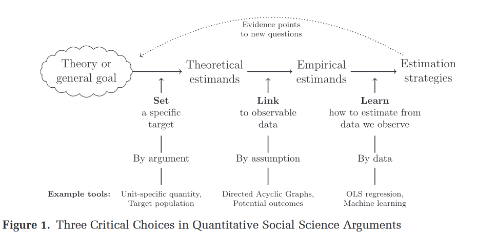

Lundberg, I., Johnson, R., & Stewart, B. M. (2021). What Is Your Estimand? Defining the Target Quantity Connects Statistical Evidence to Theory. *American Sociological Review*, 86(3), 532–565.

# Directed Acyclic Graphs

## Intro to DAGs for causal systems

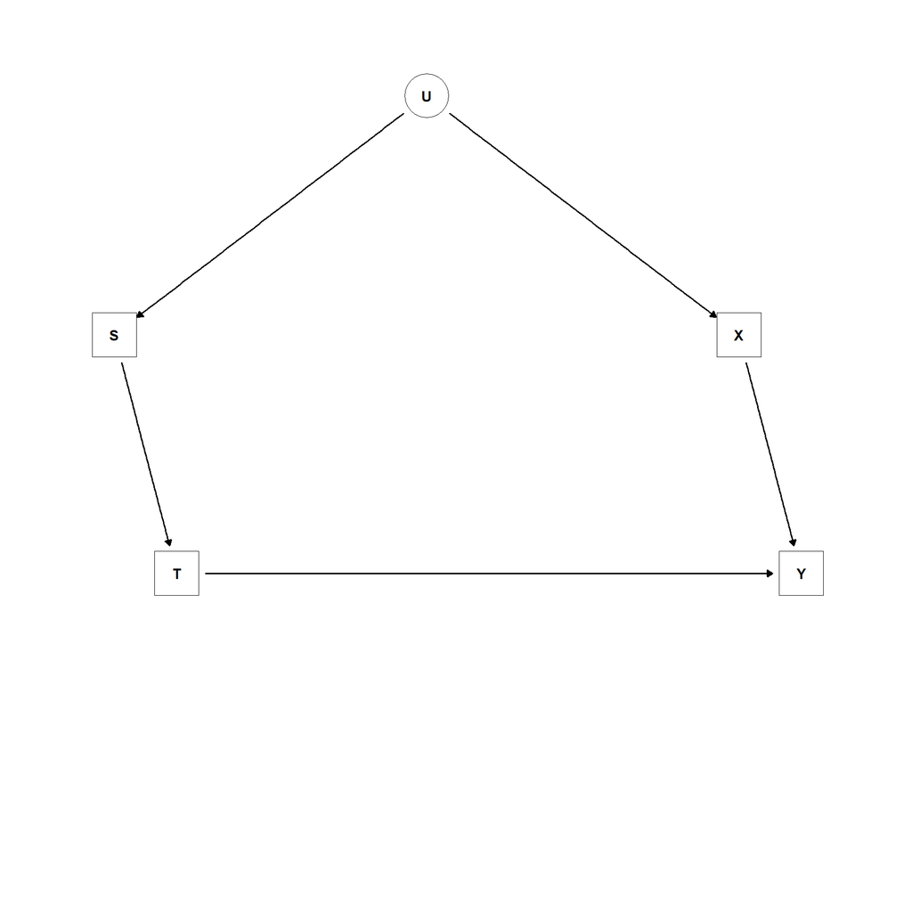

- **Y**: outcome
- **T**: treatment
- **U**: unobserved confounder
- **S**: affects selection into T
- **X**: affects Y directly

## Regression vs. matching/weighting

**Regression** attempts to identify $T \rightarrow Y$ by adjusting for $X$ while regressing $Y$ on $T$

**Matching and weighting** attempt to identify $T \rightarrow Y$ by ensuring that $S$ has the same distribution for all values of $T$

Both are strategies to **close the backdoor path** between $T$ and $Y$

## Caveat: neither works here

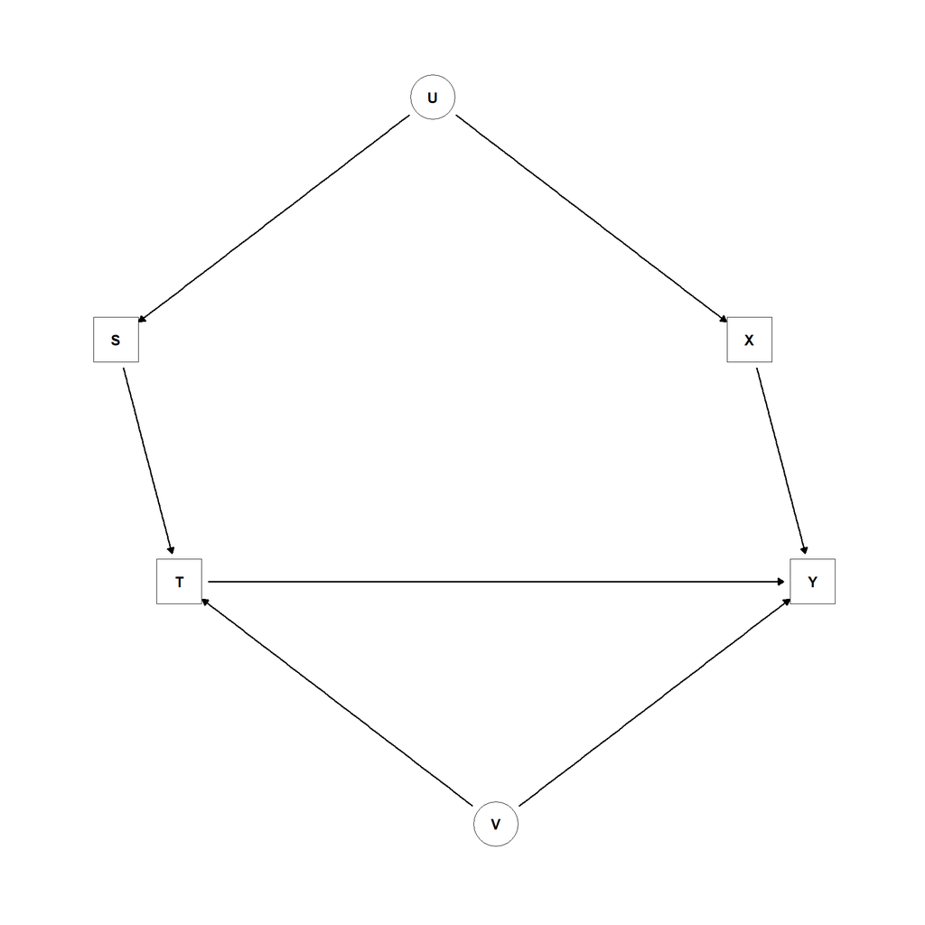

These techniques only allow us to account for *observed* differences between treated and control cases. If $V$ is unobserved, we can’t close the backdoor path with either of these approaches.